# Previsión de demanda

Joel Ramirez

2025

### Problema:

Predecir la demanda futura (columna Demand), usando las variables históricas (ventas, inventario, precio, promociones, clima, etc.) y mostrar cómo influyen promociones, descuentos, clima o precios de la competencia.

### Metodología aplicada

#### Preparación de los datos

Obtengo el archivo y lo muestro en consola

```r
df <- read.csv("C:/Users/User/OneDrive/Desktop/Previsión de demanda/sales_data.csv", sep=",", header = TRUE)
head(df)
```

```
##         Date Store.ID Product.ID    Category Region Inventory.Level Units.Sold
## 1 2022-01-01     S001      P0001 Electronics  North             195        102
## 2 2022-01-01     S001      P0002    Clothing  North             117        117
## 3 2022-01-01     S001      P0003    Clothing  North             247        114
## 4 2022-01-01     S001      P0004 Electronics  North             139         45
## 5 2022-01-01     S001      P0005   Groceries  North             152         65
## 6 2022-01-01     S001      P0006        Toys  North             209         60
##   Units.Ordered Price Discount Weather.Condition Promotion Competitor.Pricing
## 1           252 72.72        5             Snowy         0              85.73
## 2           249 80.16       15             Snowy         1              92.02
## 3           612 62.94       10             Snowy         1              60.08
## 4           102 87.63       10             Snowy         0              85.19
## 5           271 54.41        0             Snowy         0              51.63
## 6             0 35.53        0             Snowy         0              40.01
##   Seasonality Epidemic Demand
## 1      Winter        0    115
## 2      Winter        0    229
## 3      Winter        0    157
## 4      Winter        0     52
## 5      Winter        0     59
## 6      Winter        0     55
```

```r
library(dplyr)
df <- df %>% filter(Category == "Electronics")
```

Tamaño del dataset

```r
dim(df)
```

```
## [1] 9120   16
```

Estructura y tipos de datos

```r
str(df)
```

```
## 'data.frame':    9120 obs. of  16 variables:
##  $ Date              : chr  "2022-01-01" "2022-01-01" "2022-01-01" "2022-01-01" ...
##  $ Store.ID          : chr  "S001" "S001" "S001" "S002" ...
##  $ Product.ID        : chr  "P0001" "P0004" "P0008" "P0005" ...
##  $ Category          : chr  "Electronics" "Electronics" "Electronics" "Electronics" ...
##  $ Region            : chr  "North" "North" "North" "South" ...
##  $ Inventory.Level   : int  195 139 244 155 197 153 122 159 292 111 ...
##  $ Units.Sold        : int  102 45 42 103 78 69 122 157 80 111 ...
##  $ Units.Ordered     : int  252 102 0 334 413 289 127 293 0 113 ...
##  $ Price             : num  72.7 87.6 37.8 92.3 78.9 ...
##  $ Discount          : int  5 10 5 0 0 10 20 10 10 0 ...
##  $ Weather.Condition : chr  "Snowy" "Snowy" "Snowy" "Cloudy" ...
##  $ Promotion         : int  0 0 0 0 0 1 1 0 0 0 ...
##  $ Competitor.Pricing: num  85.7 85.2 44.9 104.7 69.8 ...
##  $ Seasonality       : chr  "Winter" "Winter" "Winter" "Winter" ...
##  $ Epidemic          : int  0 0 0 0 0 0 0 0 0 0 ...
##  $ Demand            : int  115 52 61 94 122 63 126 149 108 103 ...
```

Estadísticas básicas

```r
summary(df)
```

```
##      Date             Store.ID          Product.ID          Category
##  Length:9120        Length:9120        Length:9120        Length:9120
##  Class :character   Class :character   Class :character   Class :character
##  Mode  :character   Mode  :character   Mode  :character   Mode  :character
##
##
##
##     Region          Inventory.Level    Units.Sold     Units.Ordered
##  Length:9120        Min.   :   0.0   Min.   :  0.00   Min.   :   0.00
##  Class :character   1st Qu.: 133.0   1st Qu.: 55.00   1st Qu.:   0.00
##  Mode  :character   Median : 228.0   Median : 79.00   Median :   0.00
##                     Mean   : 289.3   Mean   : 83.04   Mean   :  83.34
##                     3rd Qu.: 387.2   3rd Qu.:106.00   3rd Qu.: 119.00
##                     Max.   :1968.0   Max.   :305.00   Max.   :1223.00
##      Price           Discount      Weather.Condition    Promotion
##  Min.   : 24.47   Min.   : 0.000   Length:9120        Min.   :0.0000
##  1st Qu.: 62.80   1st Qu.: 5.000   Class :character   1st Qu.:0.0000
##  Median : 83.79   Median :10.000   Mode  :character   Median :0.0000
##  Mean   : 83.17   Mean   : 9.055                      Mean   :0.3289
##  3rd Qu.:104.22   3rd Qu.:10.000                      3rd Qu.:1.0000
##  Max.   :177.36   Max.   :25.000                      Max.   :1.0000
##  Competitor.Pricing Seasonality           Epidemic       Demand
##  Min.   : 25.46     Length:9120        Min.   :0.0   Min.   :  4.00
##  1st Qu.: 63.34     Class :character   1st Qu.:0.0   1st Qu.: 68.00
##  Median : 85.11     Mode  :character   Median :0.0   Median : 95.00
##  Mean   : 85.20                        Mean   :0.2   Mean   : 97.48
##  3rd Qu.:106.61                        3rd Qu.:0.0   3rd Qu.:122.00
##  Max.   :188.70                        Max.   :1.0   Max.   :339.00
```

Garantizo que los nombres de las columnas sean solo letras, numeros o guiones bajos

```r
names(df) <- make.names(names(df), unique = TRUE)
```

Contamos cuantos productos se tienen

```r
library(dplyr)
num_productos <- df %>% summarise(total_productos = n_distinct(Product.ID))
print(num_productos)
```

```
##   total_productos
## 1              10
```

Cuantas tiendas:

```r
num_productos <- df %>% summarise(total_tiendas = n_distinct(Store.ID))
print(num_productos)
```

```
##   total_tiendas
## 1             5
```

##### Analisis de valores faltantes

###### Estudio de outliers

Valores faltantes:

```r
library(naniar)
miss_var_summary(df)
```

```
## # A tibble: 16 × 3
##    variable           n_miss pct_miss
##    <chr>               <int>    <num>
##  1 Date                    0        0
##  2 Store.ID                0        0
##  3 Product.ID              0        0
##  4 Category                0        0
##  5 Region                  0        0
##  6 Inventory.Level         0        0
##  7 Units.Sold              0        0
##  8 Units.Ordered           0        0
##  9 Price                   0        0
## 10 Discount                0        0
## 11 Weather.Condition       0        0
## 12 Promotion               0        0
## 13 Competitor.Pricing      0        0
## 14 Seasonality             0        0
## 15 Epidemic                0        0
## 16 Demand                  0        0
```

Valores atípicos

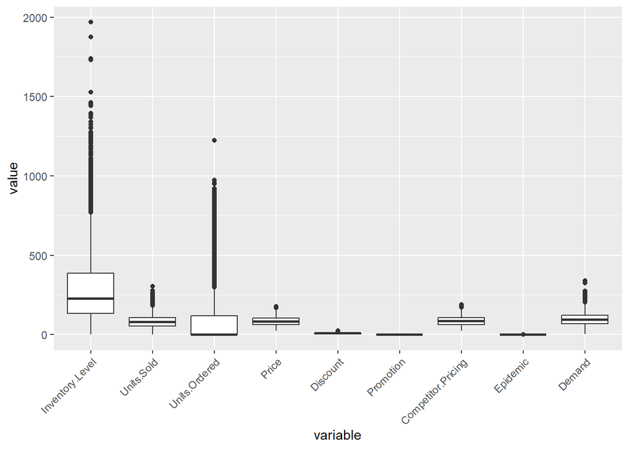

```r
library(ggplot2)
numeric_vars <- sapply(df, is.numeric)
num_df <- df[, numeric_vars]

# Boxplots para detectar outliers
library(reshape2)
num_df_melt <- melt(num_df)
ggplot(num_df_melt, aes(x = variable, y = value)) +
  geom_boxplot() +
  theme(axis.text.x = element_text(angle = 45, hjust = 1))
```

Fecha a formato Date:

```r
df$Date <- as.Date(df$Date)
df$Weekday <- weekdays(df$Date)
df$Month <- format(df$Date, "%m")
df$Weekday <- as.factor(df$Weekday)
df$Month <- as.factor(df$Month)
df$Year <- as.factor(format(df$Date, "%Y"))

head(df)
```

```
##         Date Store.ID Product.ID    Category Region Inventory.Level Units.Sold
## 1 2022-01-01     S001      P0001 Electronics  North             195        102
## 2 2022-01-01     S001      P0004 Electronics  North             139         45
## 3 2022-01-01     S001      P0008 Electronics  North             244         42
## 4 2022-01-01     S002      P0005 Electronics  South             155        103
## 5 2022-01-01     S002      P0012 Electronics  South             197         78
## 6 2022-01-01     S002      P0014 Electronics  South             153         69
##   Units.Ordered  Price Discount Weather.Condition Promotion Competitor.Pricing
## 1           252  72.72        5             Snowy         0              85.73
## 2           102  87.63       10             Snowy         0              85.19
## 3             0  37.79        5             Snowy         0              44.85
## 4           334  92.35        0            Cloudy         0             104.72
## 5           413  78.86        0            Cloudy         0              69.84
## 6           289 100.18       10            Cloudy         1             108.96
##   Seasonality Epidemic Demand Weekday Month Year
## 1      Winter        0    115  sábado    01 2022
## 2      Winter        0     52  sábado    01 2022
## 3      Winter        0     61  sábado    01 2022
## 4      Winter        0     94  sábado    01 2022
## 5      Winter        0    122  sábado    01 2022
## 6      Winter        0     63  sábado    01 2022
```

#### Exploracion de los datos:

**Visualización de patrones**

Ver qué producto tiene mayor demanda en qué condiciones (promociones, clima, región).

Producto y region vs condicion climatica

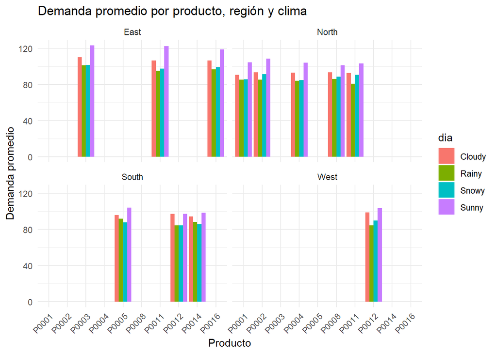

```r
library(dplyr)
library(ggplot2)

promo_region_demand <- df %>%
  group_by(Product.ID, Region, Weather.Condition) %>%
  summarise(Demanda_Promedio = mean(Demand, na.rm = TRUE)) %>%
  ungroup()
ggplot(promo_region_demand, aes(x = Product.ID, y = Demanda_Promedio, fill = factor(Weather.Condition))) +
  geom_col(position = "dodge") +
  facet_wrap(~ Region) +
  labs(title = "Demanda promedio por producto, región y clima",
       x = "Producto",
       y = "Demanda promedio",
       fill = "dia") +
  theme_minimal() +
  theme(axis.text.x = element_text(angle = 45, hjust = 1))
```

Producto y region vs promoción

```r
promo_region_demand <- df %>%
  group_by(Product.ID, Region, Promotion) %>%
  summarise(Demanda_Promedio = mean(Demand, na.rm = TRUE)) %>%
  ungroup()
```

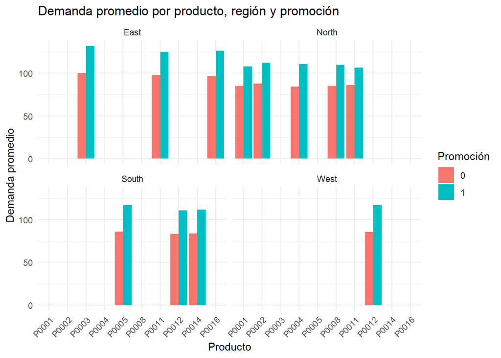

```r
ggplot(promo_region_demand, aes(x = Product.ID, y = Demanda_Promedio, fill = factor(Promotion))) +
  geom_col(position = "dodge") +
  facet_wrap(~ Region) +
  labs(title = "Demanda promedio por producto, región y promoción",
       x = "Producto",
       y = "Demanda promedio",
       fill = "Promoción") +
  theme_minimal() +
  theme(axis.text.x = element_text(angle = 45, hjust = 1))
```

Producto y region vs Estación

```r
promo_region_demand <- df %>%
  group_by(Product.ID, Region, Seasonality) %>%
  summarise(Demanda_Promedio = mean(Demand, na.rm = TRUE)) %>%
  ungroup()
```

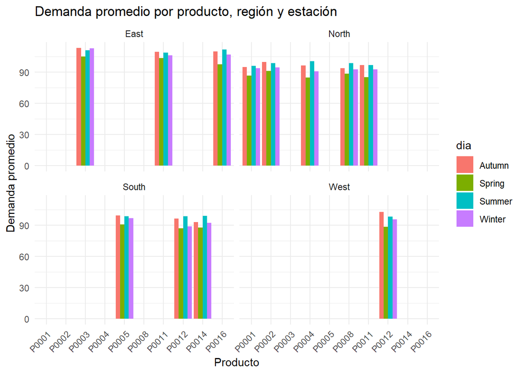

```r
ggplot(promo_region_demand, aes(x = Product.ID, y = Demanda_Promedio, fill = factor(Seasonality))) +
  geom_col(position = "dodge") +
  facet_wrap(~ Region) +
  labs(title = "Demanda promedio por producto, región y estación",
       x = "Producto",
       y = "Demanda promedio",
       fill = "dia") +
  theme_minimal() +
  theme(axis.text.x = element_text(angle = 45, hjust = 1))
```

Producto y region vs Precio

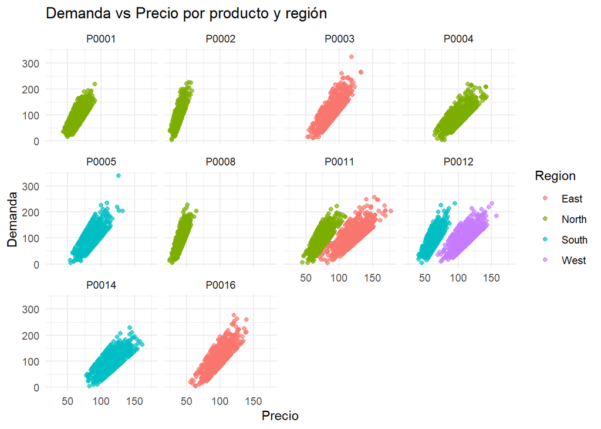

```r
ggplot(df, aes(x = Price, y = Demand, color = Region)) +
  geom_point(alpha = 0.7) +
  facet_wrap(~ Product.ID) +
  labs(title = "Demanda vs Precio por producto y región",
       x = "Precio",
       y = "Demanda") +
  theme_minimal()
```

Producto y region vs Epidemia

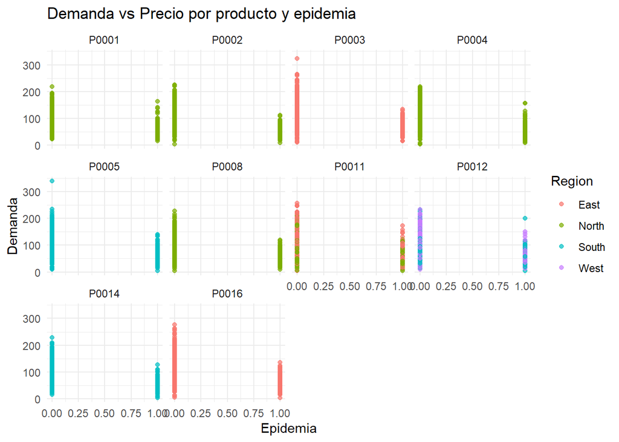

```r
ggplot(df, aes(x = Epidemic, y = Demand, color = Region)) +
  geom_point(alpha = 0.7) +
  facet_wrap(~ Product.ID) +
  labs(title = "Demanda vs Precio por producto y epidemia",
       x = "Epidemia",
       y = "Demanda") +
  theme_minimal()
```

**Detectar picos o caídas en la demanda en días específicos**

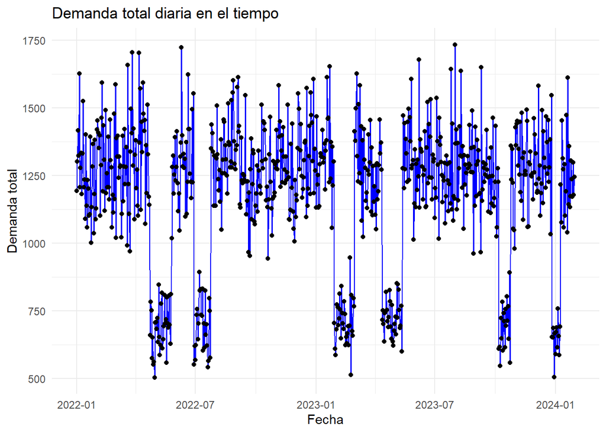

```r
library(dplyr)
library(ggplot2)
library(lubridate)
# Convertir Date a formato Date si no lo está
df$Date <- as.Date(df$Date)

# Agregar demanda diaria total (si tienes varios productos o tiendas)
demanda_diaria <- df %>%
  group_by(Date) %>%
  summarise(Demanda_Total = sum(Demand, na.rm = TRUE)) %>%
  arrange(Date)


ggplot(demanda_diaria, aes(x = Date, y = Demanda_Total)) +
  geom_line(color = "blue") +
  geom_point() +
  labs(title = "Demanda total diaria en el tiempo",
       x = "Fecha",
       y = "Demanda total") +
  theme_minimal()
```

Agregamos promedio móvil:

```r
library(zoo)
```

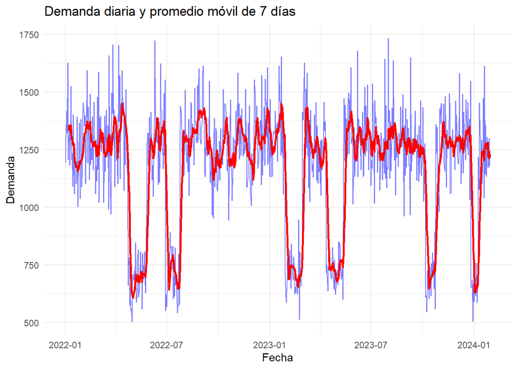

```r
demanda_diaria <- demanda_diaria %>%
  mutate(Promedio_Movil_7d = rollmean(Demanda_Total, k = 7, fill = NA, align = "right"))


ggplot(demanda_diaria, aes(x = Date)) +
  geom_line(aes(y = Demanda_Total), color = "blue", alpha = 0.5) +
  geom_line(aes(y = Promedio_Movil_7d), color = "red", size = 1) +
  labs(title = "Demanda diaria y promedio móvil de 7 días",
       x = "Fecha",
       y = "Demanda") +
  theme_minimal()
```

Obtenemos los picos y caidas:

```r
umbral_pico <- quantile(demanda_diaria$Demanda_Total, 0.95, na.rm = TRUE)  # 95 percentil

picos <- demanda_diaria %>%
  filter(Demanda_Total >= umbral_pico)

print(picos)
```

```
## # A tibble: 38 × 3
##    Date       Demanda_Total Promedio_Movil_7d
##    <date>             <int>             <dbl>
##  1 2022-01-05          1627               NA
##  2 2022-01-11          1525             1355.
##  3 2022-02-09          1593             1372
##  4 2022-03-01          1587             1266.
##  5 2022-03-20          1658             1315.
##  6 2022-03-27          1705             1320.
##  7 2022-04-06          1704             1303.
##  8 2022-04-08          1572             1337.
##  9 2022-04-12          1594             1450.
## 10 2022-06-10          1724             1284.
## # ℹ 28 more rows
```

```r
library(lubridate)
library(dplyr)

picos %>%
  mutate(Mes = floor_date(Date, "month")) %>%
  group_by(Mes) %>%
  summarise(Num_Picos = n()) %>%
  arrange(Mes)
```

```
## # A tibble: 18 × 2
##    Mes        Num_Picos
##    <date>         <int>
##  1 2022-01-01         2
##  2 2022-02-01         1
##  3 2022-03-01         3
##  4 2022-04-01         3
##  5 2022-06-01         3
##  6 2022-08-01         3
##  7 2022-09-01         3
##  8 2022-11-01         1
##  9 2022-12-01         4
## 10 2023-01-01         2
## 11 2023-03-01         2
## 12 2023-05-01         1
## 13 2023-06-01         2
## 14 2023-07-01         2
## 15 2023-08-01         2
## 16 2023-09-01         1
## 17 2023-12-01         2
## 18 2024-01-01         1
```

```r
umbral_caida <- quantile(demanda_diaria$Demanda_Total, 0.05, na.rm = TRUE)

caidas <- demanda_diaria %>%
  filter(Demanda_Total <= umbral_caida)

print(caidas)
```

```
## # A tibble: 38 × 3
##    Date       Demanda_Total Promedio_Movil_7d
##    <date>             <int>             <dbl>
##  1 2022-04-26           575              916.
##  2 2022-04-28           551              731.
##  3 2022-04-29           562              648.
##  4 2022-04-30           504              625.
##  5 2022-05-05           635              646.
##  6 2022-05-08           587              691.
##  7 2022-05-09           624              679
##  8 2022-05-12           612              702.
##  9 2022-05-18           558              677.
## 10 2022-05-24           628              697.
## # ℹ 28 more rows
```

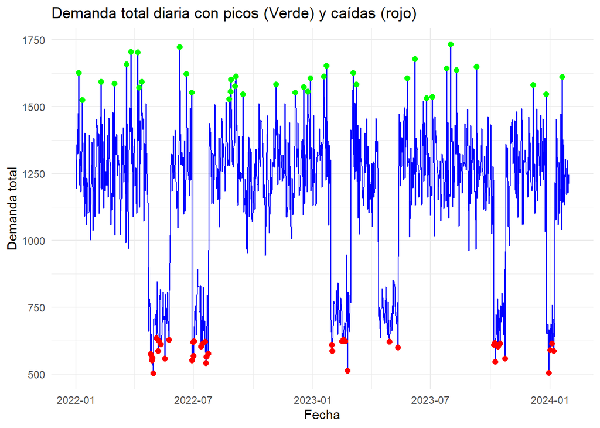

```r
ggplot(demanda_diaria, aes(x = Date, y = Demanda_Total)) +
  geom_line(color = "blue") +
  geom_point(data = picos, aes(x = Date, y = Demanda_Total), color = "green", size = 2) +
  geom_point(data = caidas, aes(x = Date, y = Demanda_Total), color = "red", size = 2) +
  labs(title = "Demanda total diaria con picos (Verde) y caídas (rojo)",
       x = "Fecha",
       y = "Demanda total") +
  theme_minimal()
```

Obtenemos los registros en los que se visualizan los picos y caidas:

```r
library(dplyr)

# Registros completos para días con picos de demanda
registros_picos <- df %>%
  filter(Date %in% picos$Date)

# Registros completos para días con caídas de demanda
registros_caidas <- df %>%
  filter(Date %in% caidas$Date)

# Mostrar algunos registros para verificar
head(registros_picos)
```

```
##         Date Store.ID Product.ID    Category Region Inventory.Level Units.Sold
## 1 2022-01-05     S001      P0001 Electronics  North             319        129
## 2 2022-01-05     S001      P0004 Electronics  North             184         38
## 3 2022-01-05     S001      P0008 Electronics  North             141         57
## 4 2022-01-05     S002      P0005 Electronics  South             334        107
## 5 2022-01-05     S002      P0012 Electronics  South             413         60
## 6 2022-01-05     S002      P0014 Electronics  South             289        171
##   Units.Ordered  Price Discount Weather.Condition Promotion Competitor.Pricing
## 1             0  59.56       25             Snowy         1              57.34
## 2             0  76.08       25             Snowy         1              75.04
## 3             0  39.03       10             Snowy         1              42.99
## 4             0  95.04       15             Snowy         1             113.93
## 5             0  56.28       15             Snowy         1              61.95
## 6             0 126.06       20             Snowy         1             111.81
##   Seasonality Epidemic Demand   Weekday Month Year
## 1      Winter        0    110 miércoles    01 2022
## 2      Winter        0     62 miércoles    01 2022
## 3      Winter        0     85 miércoles    01 2022
## 4      Winter        0    157 miércoles    01 2022
## 5      Winter        0     84 miércoles    01 2022
## 6      Winter        0    155 miércoles    01 2022
```

```r
head(registros_caidas)
```

```
##         Date Store.ID Product.ID    Category Region Inventory.Level Units.Sold
## 1 2022-04-26     S001      P0001 Electronics  North              83         40
## 2 2022-04-26     S001      P0004 Electronics  North             141         37
## 3 2022-04-26     S001      P0008 Electronics  North              73         48
## 4 2022-04-26     S002      P0005 Electronics  South             427         34
## 5 2022-04-26     S002      P0012 Electronics  South             917         43
## 6 2022-04-26     S002      P0014 Electronics  South             376         47
##   Units.Ordered  Price Discount Weather.Condition Promotion Competitor.Pricing
## 1           119  54.53       15             Rainy         1              46.52
## 2             0  91.00        0             Rainy         0              90.16
## 3            79  40.92        0             Rainy         0              45.94
## 4             0  71.75       10             Rainy         0              81.04
## 5             0  51.69       10             Rainy         0              59.63
## 6             0 103.82        0             Rainy         0             114.08
##   Seasonality Epidemic Demand Weekday Month Year
## 1      Spring        1     50  martes    04 2022
## 2      Spring        1     35  martes    04 2022
## 3      Spring        1     68  martes    04 2022
## 4      Spring        1     53  martes    04 2022
## 5      Spring        1     45  martes    04 2022
## 6      Spring        1     45  martes    04 2022
```

**Factores que causaron la caida de la demanda**

Mostramos los factores mediante un arbol de decisión:

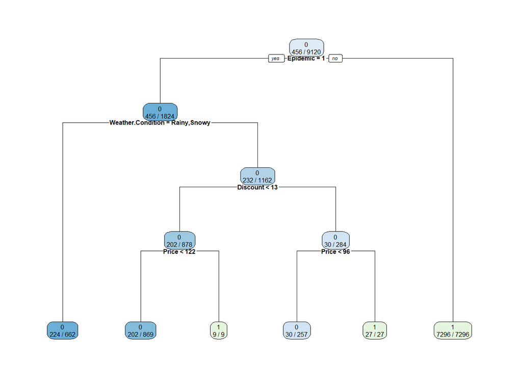

```r
library(rpart)
library(rpart.plot)
library(dplyr)

# Crear variable binaria Caida
df <- df %>%
  mutate(Caida = ifelse(Date %in% caidas$Date, 0, 1))

# Convertir variables categóricas a factor
df$Promotion <- as.factor(df$Promotion)
df$Weather.Condition <- as.factor(df$Weather.Condition)
df$Region <- as.factor(df$Region)

# Entrenar árbol con pesos balanceados y control de complejidad
arbol <- rpart(Caida ~ Price + Discount + Promotion + Weather.Condition + Region + Inventory.Level + Epidemic,
               data = df,
               method = "class",
               parms = list(prior = c(0.5, 0.5)),
               control = rpart.control(minsplit = 10, cp = 0.001, maxdepth = 4))

rpart.plot(arbol, extra = 2, cex = 0.5, fallen.leaves = TRUE)
```

Importancia de cada variable segun el arbol

```r
print(arbol$variable.importance)
```

```
##          Epidemic             Price          Discount Weather.Condition
##        3316.36364          83.20866          18.42569          17.21218
##         Promotion
##          12.19729
```

Mostramos graficamente ello:

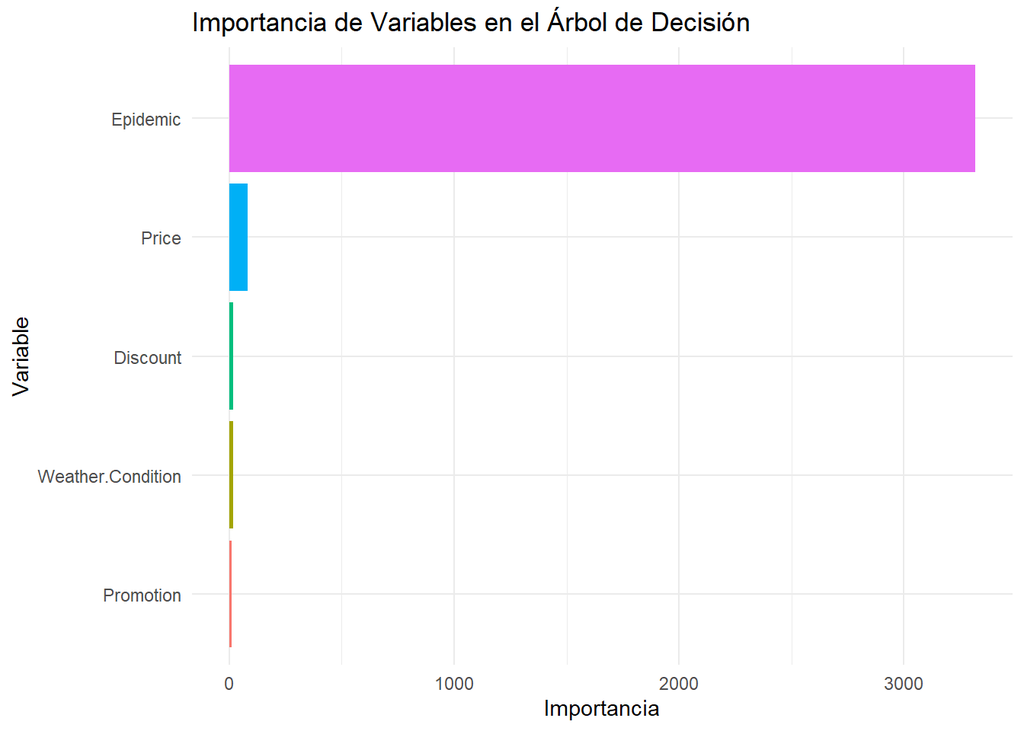

```r
# Extraer importancia de variables del árbol
importancia <- arbol$variable.importance

# Crear dataframe para ggplot
df_importancia <- data.frame(
  Variable = names(importancia),
  Importancia = as.numeric(importancia)
)

# Ordenar variables por importancia descendente
df_importancia$Variable <- factor(df_importancia$Variable, levels = df_importancia$Variable[order(df_importancia$Importancia)])

# Graficar barras horizontales
ggplot(df_importancia, aes(x = Variable, y = Importancia, fill = Variable)) +
  geom_bar(stat = "identity") +
  coord_flip() +
  labs(title = "Importancia de Variables en el Árbol de Decisión",
       x = "Variable",
       y = "Importancia") +
  theme_minimal() +
  theme(legend.position = "none")
```

**Como influyen los precios de la competencia con la demanda**

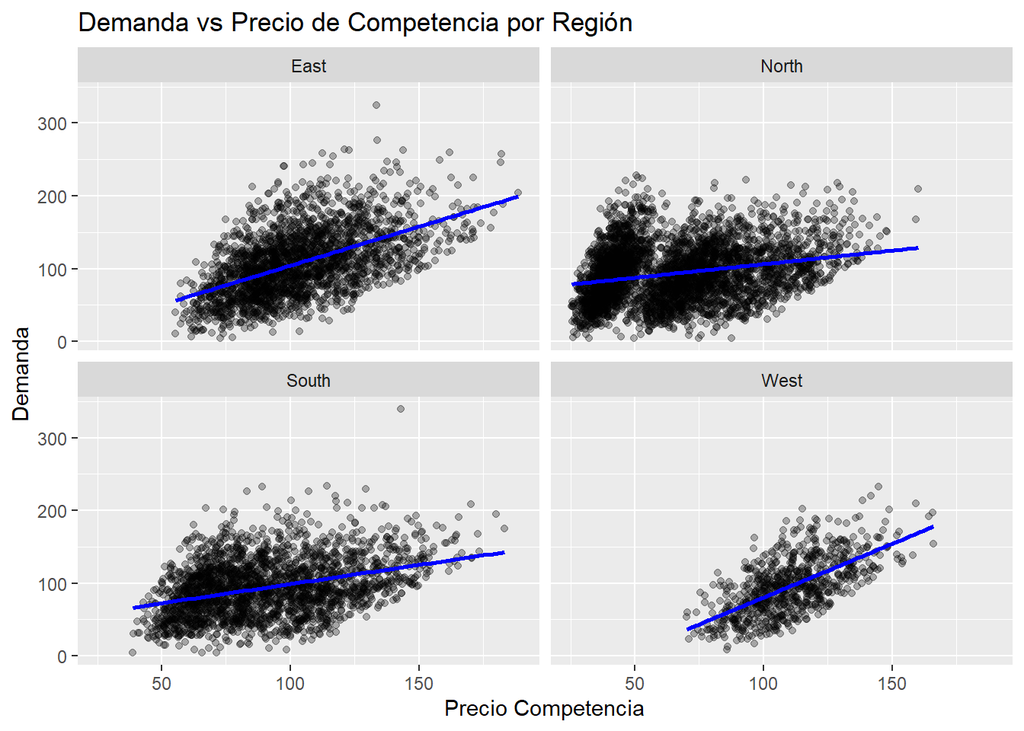

```r
library(ggplot2)

ggplot(df, aes(x = Competitor.Pricing, y = Demand)) +
  geom_point(alpha = 0.3) +
  facet_wrap(~ Region) +
  geom_smooth(method = "lm", se = FALSE, color = "blue") +
  labs(title = "Demanda vs Precio de Competencia por Región",
       x = "Precio Competencia",
       y = "Demanda")
```

**Evaluaamos si las variables categóricas tienen un efecto significativo sobre la variable numérica Demanda**

Demanda según Región

```r
anova_region <- aov(Demand ~ Region, data = df)
summary(anova_region)
```

```
##               Df   Sum Sq Mean Sq F value Pr(>F)
## Region         3   339114  113038   70.28 <2e-16 ***
## Residuals   9116 14661093    1608
## ---
## Signif. codes:  0 '***' 0.001 '**' 0.01 '*' 0.05 '.' 0.1 ' ' 1
```

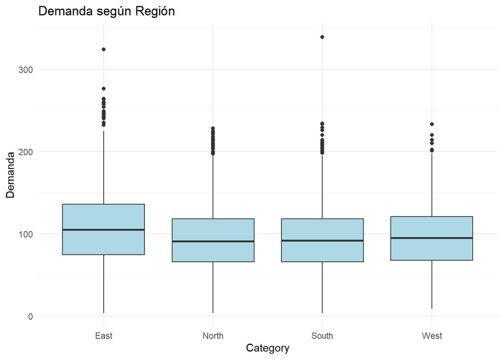

```r
ggplot(df, aes(x = Region, y = Demand)) +
  geom_boxplot(fill = "lightblue") +
  theme_minimal() +
  labs(title = "Demanda según Región",
       x = "Category",
       y = "Demanda")
```

Demanda según clima

```r
anova_weather <- aov(Demand ~ Weather.Condition, data = df)
summary(anova_weather)
```

```
##                     Df   Sum Sq Mean Sq F value Pr(>F)
## Weather.Condition    3   485590  161863   101.7 <2e-16 ***
## Residuals         9116 14514617    1592
## ---
## Signif. codes:  0 '***' 0.001 '**' 0.01 '*' 0.05 '.' 0.1 ' ' 1
```

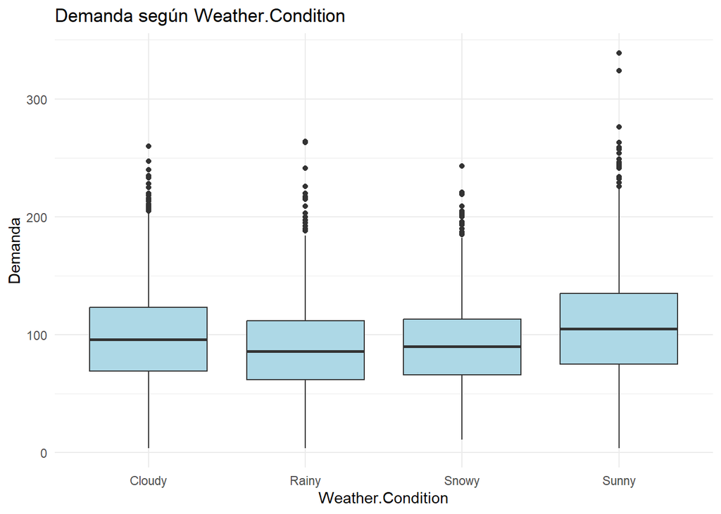

```r
ggplot(df, aes(x = Weather.Condition, y = Demand)) +
  geom_boxplot(fill = "lightblue") +
  theme_minimal() +
  labs(title = "Demanda según Weather.Condition",
       x = "Weather.Condition",
       y = "Demanda")
```

Demanda según Promocion

```r
anova_promotion <- aov(Demand ~ Promotion, data = df)
summary(anova_promotion)
```

```
##               Df   Sum Sq Mean Sq F value Pr(>F)
## Promotion      1  1475470 1475470   994.7 <2e-16 ***
## Residuals   9118 13524737    1483
## ---
## Signif. codes:  0 '***' 0.001 '**' 0.01 '*' 0.05 '.' 0.1 ' ' 1
```

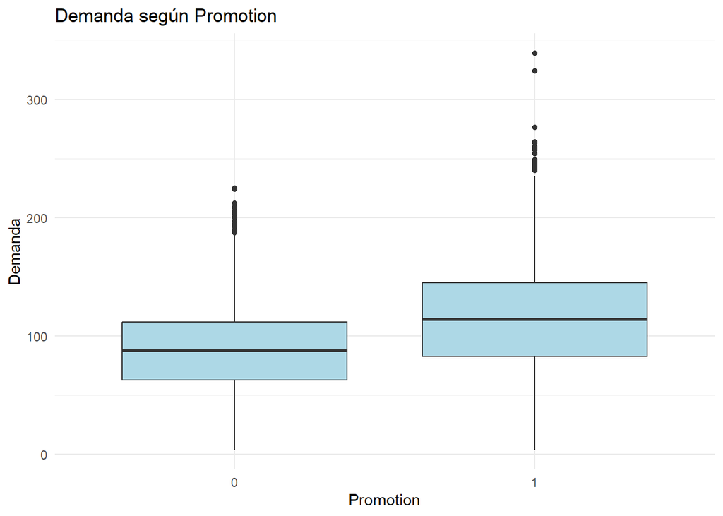

```r
ggplot(df, aes(x = Promotion, y = Demand)) +
  geom_boxplot(fill = "lightblue") +
  theme_minimal() +
  labs(title = "Demanda según Promotion",
       x = "Promotion",
       y = "Demanda")
```

Demanda según estación del año

```r
anova_seasonality <- aov(Demand ~ Seasonality, data = df)
summary(anova_seasonality)
```

```
##               Df   Sum Sq Mean Sq F value Pr(>F)
## Seasonality    3   138069   46023   28.23 <2e-16 ***
## Residuals   9116 14862138    1630
## ---
## Signif. codes:  0 '***' 0.001 '**' 0.01 '*' 0.05 '.' 0.1 ' ' 1
```

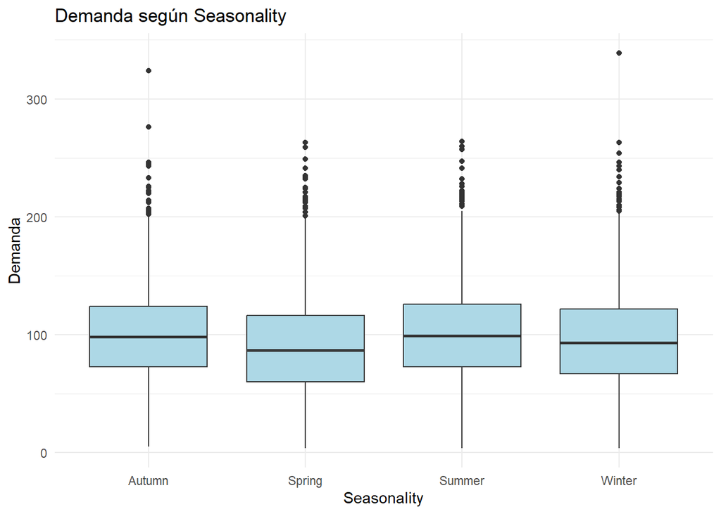

```r
ggplot(df, aes(x = Seasonality, y = Demand)) +
  geom_boxplot(fill = "lightblue") +
  theme_minimal() +
  labs(title = "Demanda según Seasonality",
       x = "Seasonality",
       y = "Demanda")
```

Demanda según Dia de semana

```r
anova_weekday <- aov(Demand ~ Weekday, data = df)
summary(anova_weekday)
```

```
##               Df   Sum Sq Mean Sq F value Pr(>F)
## Weekday        6     2991   498.6   0.303  0.936
## Residuals   9113 14997216  1645.7
```

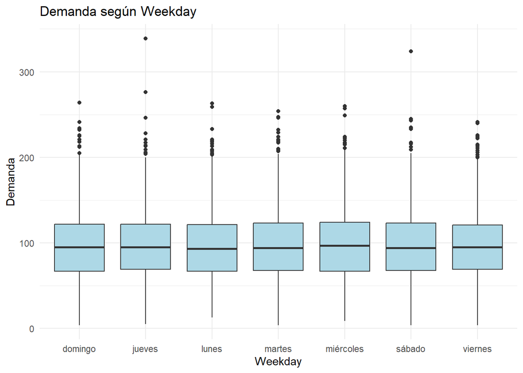

```r
ggplot(df, aes(x = Weekday, y = Demand)) +
  geom_boxplot(fill = "lightblue") +
  theme_minimal() +
  labs(title = "Demanda según Weekday",
       x = "Weekday",
       y = "Demanda")
```

Demanda según Epidemia

```r
anova_weekday <- aov(Demand ~ Epidemic, data = df)
summary(anova_weekday)
```

```
##               Df   Sum Sq Mean Sq F value Pr(>F)
## Epidemic       1  3530580 3530580    2807 <2e-16 ***
## Residuals   9118 11469627    1258
## ---
## Signif. codes:  0 '***' 0.001 '**' 0.01 '*' 0.05 '.' 0.1 ' ' 1
```

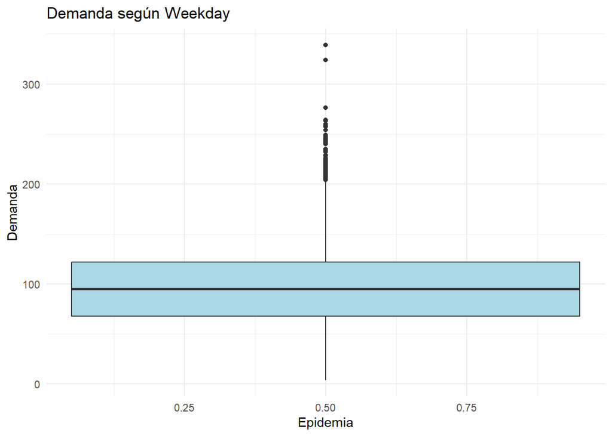

```r
ggplot(df, aes(x = Epidemic, y = Demand)) +
  geom_boxplot(fill = "lightblue") +
  theme_minimal() +
  labs(title = "Demanda según Weekday",
       x = "Epidemia",
       y = "Demanda")
```

**Variables mas importantes para pronosticar según LASSO**

```r
library(glmnet)
library(dplyr)
library(Matrix)

# 1. Preparar datos

# Seleccionar variables predictoras y respuesta
# Incluye variables numéricas y factores (Promotion, Weather.Condition, Region)

df_model <- df %>%
  select(Demand, Price, Discount, Promotion, Weather.Condition, Region, Inventory.Level, Competitor.Pricing, Epidemic)

# Convertir factores a dummies (one-hot encoding)
# model.matrix crea la matriz de diseño con variables dummy automáticamente

x <- model.matrix(Demand ~ . , data = df_model)[, -1]  # quitar intercepto
y <- df_model$Demand

# 2. Entrenar Lasso con validación cruzada
set.seed(123)  # para reproducibilidad
cv_lasso <- cv.glmnet(x, y, alpha = 1, nfolds = 10)

# Mejor lambda para lasso (penalización)
best_lambda <- cv_lasso$lambda.min

# 3. Ajustar modelo final con mejor lambda
modelo_lasso <- glmnet(x, y, alpha = 1, lambda = best_lambda)

# 4. Coeficientes del modelo
coeficientes <- coef(modelo_lasso)
print(coeficientes)
```

```
## 13 x 1 sparse Matrix of class "dgCMatrix"
##                                   s0
## (Intercept)             47.709692434
## Price                    0.475758411
## Discount                 0.550764151
## Promotion1              22.533993694
## Weather.ConditionRainy  -6.923894524
## Weather.ConditionSnowy  -7.808868092
## Weather.ConditionSunny   8.805684220
## RegionNorth              6.377123649
## RegionSouth             -6.309249491
## RegionWest             -16.110712985
## Inventory.Level         -0.002564394
## Competitor.Pricing       0.085758584
## Epidemic               -41.836221743
```

```r
# 5. Variables con coeficientes distintos de cero (importantes)
vars_importantes <- rownames(coeficientes)[which(coeficientes != 0)]
vars_importantes <- vars_importantes[vars_importantes != "(Intercept)"]
cat("Variables importantes seleccionadas por Lasso:\n")
```

```
## Variables importantes seleccionadas por Lasso:
```

```r
print(vars_importantes)
```

```
##  [1] "Price"                  "Discount"               "Promotion1"
##  [4] "Weather.ConditionRainy" "Weather.ConditionSnowy" "Weather.ConditionSunny"
##  [7] "RegionNorth"            "RegionSouth"            "RegionWest"
## [10] "Inventory.Level"        "Competitor.Pricing"     "Epidemic"
```

Grafico:

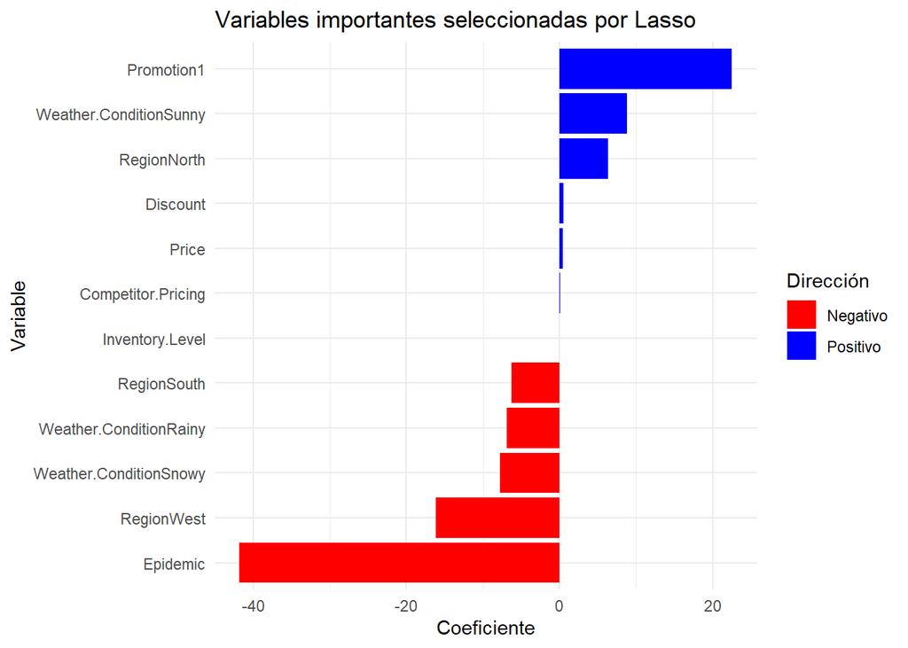

```r
library(ggplot2)
library(dplyr)

# Extraer coeficientes del modelo Lasso (excluyendo intercepto)
coef_lasso <- as.matrix(coeficientes)
coef_df <- data.frame(
  Variable = rownames(coef_lasso),
  Coeficiente = as.numeric(coef_lasso)
) %>%
  filter(Variable != "(Intercept)" & Coeficiente != 0) %>%
  arrange(desc(abs(Coeficiente)))

# Graficar coeficientes
ggplot(coef_df, aes(x = reorder(Variable, Coeficiente), y = Coeficiente, fill = Coeficiente > 0)) +
  geom_bar(stat = "identity") +
  coord_flip() +
  scale_fill_manual(values = c("red", "blue"), labels = c("Negativo", "Positivo")) +
  labs(title = "Variables importantes seleccionadas por Lasso",
       x = "Variable",
       y = "Coeficiente",
       fill = "Dirección") +
  theme_minimal()
```

**Correlaciones**

```r
library(corrplot)  # para visualización (opcional)
# Seleccionar variables numéricas independientes
vars_numericas <- df %>%
  select(Price, Discount, Inventory.Level, Competitor.Pricing)

# Calcular matriz de correlación
matriz_cor <- cor(vars_numericas, use = "complete.obs")

# Mostrar matriz en consola
print(matriz_cor)
```

```
##                           Price     Discount Inventory.Level Competitor.Pricing
## Price               1.000000000 -0.146872209     0.007239554         0.94472297
## Discount           -0.146872209  1.000000000     0.004220165        -0.14078715
## Inventory.Level     0.007239554  0.004220165     1.000000000         0.00793578
## Competitor.Pricing  0.944722973 -0.140787146     0.007935780         1.00000000
```

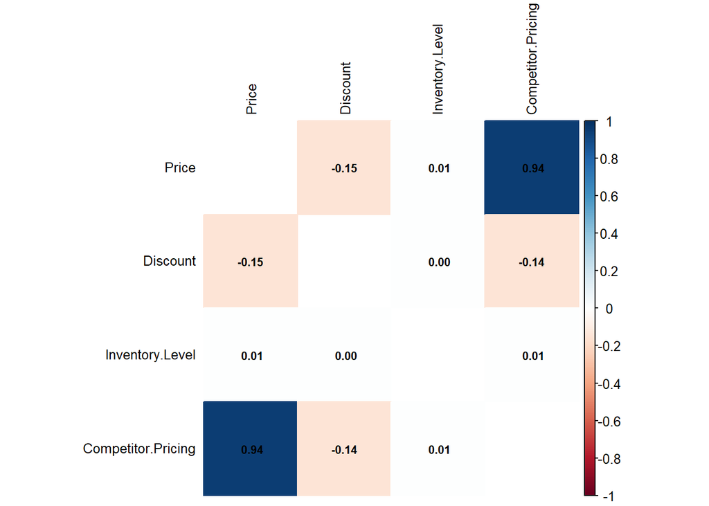

```r
corrplot(matriz_cor, method = "color", addCoef.col = "black", number.cex = 0.7,
         tl.cex = 0.8, tl.col = "black", diag = FALSE)
```

##### Preparamos el dataset para modelar:

**Transformo variables categoricas a numericas**

```r
library(dplyr)
library(caret)
# Seleccionamos las variables predictoras que incluyen categóricas y numéricas
df_model <- df %>%
  select(Demand, Price, Discount, Promotion, Weather.Condition, Region, Inventory.Level, Competitor.Pricing, Seasonality, Weekday, Epidemic)

# Aplicar codificación ordinal: convertir variables categóricas a factores y luego a numérico
df_model <- df_model %>%
  mutate(
    Promotion = as.numeric(factor(Promotion)),
    Weather.Condition = as.numeric(factor(Weather.Condition)),
    Region = as.numeric(factor(Region)),
    Seasonality = as.numeric(factor(Seasonality)),
    Weekday = as.numeric(factor(Weekday))
  )
```